# School Socioeconomic Status Context and Social Skills in Children

Philip Parker

1  
philip.parker@acu.edu.au

Taren Sanders

1  
taren.sanders@acu.edu.au

Abstract

After decades of research and intervention aimed at reducing educational and occupational inequality, inequalities persist (Reardon 2011). In response to this bleak picture, there has been a flurry of interest in social-emotional competencies driven by the research of Nobel prize-winning economist James Heckman. (Heckman 2006) argues that research and intervention on reducing educational inequality have focused too narrowly on “cognitive” abilities. Yet cognitive abilities are not the only pathway through which low socioeconomic status may stifle educational and occupational attainment. For example, social skills are a potentially powerful explanation for socioeconomic status gaps in educational and occupational attainment (Gutman and Schoon 2013). Children from low socioeconomic backgrounds (here after low SES children[^1]) appear to enter school with poorer social skills (e.g., Jerrim and Sims 2019). This is concerning as childhood social skills predict a wide variety of later life outcomes (e.g., Jones, Greenberg, and Crowley 2015). Inspired by identity economics, our research asks whether the school context in the stratified school system of Australia may exacerbate this issue. In particular, we explore whether school average socioeconomic status predicts social skills in Year 3 (age 8)—using measures of peer problems, conduct problems, and prosocial behavior. We consider if this association is independent of children’s incoming social skills at age 4, children’s own socioeconomic status, and a set of demographic and academic covariates in a representative longitudinal sample of Australian children.

## Social Skills

Of the skills that employers are looking for when hiring candidates, social skills are some of the most desirable (Rios et al. 2020). Social skills also seem to be a viable target for intervention with meta-analysis showing social and emotional learning programs have moderate effects on improving key social skills like reducing conduct problems and improving social-emotional learning skills and prosocial behavior (Durlak et al. 2011). Social skills appear to be worthwhile targets from a societal perspective given their relationship to academic achievement (Corcoran et al. 2018) and their role in predicting adult employment, crime, public assistance, substance abuse, and mental health (Jones, Greenberg, and Crowley 2015). Among young children, it is increasingly common to focus on social skills as measured by the Strengths and Difficulties Questionnaire (see Datta Gupta and Simonsen 2010; Gutman and Schoon 2013; Jerrim and Sims 2019). We use this questionnaire to measure peer problems, conduct problems, and prosocial behavior. We model social skills using both parent and teacher reports.

## Contrast Processes and Identity Economics

Children’s social skills depend in part on the context in which they develop (Jerrim and Sims 2019). There are two major forces in social psychology—assimilation and contrast (Mussweiler, Rüter, and Epstude 2004)—that may account for how school context affects children’s social skill development. Contrast processes are in operation when children’s perceptions, opinions, or behavior depend on their perceived rank order within their group. Assimilation processes are in operation when people’s perceptions, opinions, or behaviour depend on reference group norms (Kelley 1952).

The theory of *Identity Economics* implies an assimilative effect (Akerlof and Kranton 2010). Identity Economics argues that the social context of the school possesses a gravity that attracts students’ identity, values, and behavior toward the prototypical identity, values, and behavior of the school (Akerlof and Kranton 2002). School ethos and norms around behavior incentivize children to act in a manner consistent with these norms. School average socioeconomic status could, thus, affect social skills. A now large body of research shows that social skills are correlated with socioeconomic status (SES; de Laat et al. 2016; Garratt et al. 2017; McMunn et al. 2001; Rajmil et al. 2014) and, this relationship is present before children enter school (Washbrook and Waldfogel 2011). In socially stratified school systems, children of similar SES tend to be schooled together. Thus, if children assimilate to the school context they are in, as Identity Economics would suggest, we would expect school average socioeconomic status to influence the development of social skills.

(Jerrim and Sims 2019) provide one test of the potential assimilative effect of schools on social skills. They found that living in an area with selective schools is associated with better social skills when compared to children living in districts without a selective school. They also found some assimilative effects of school average SES predicting social skills using the total score of the strengths and difficulties questionnaire (SDQ). The assimilation effects they found, however, were weak. This may be because the authors used the SDQ total score—which includes a range of social and emotional behaviors—rather than focusing on specific social skill components of the SDQ. Further, assimilative effects may be non-linear. Put another way, the assimilative power of school contexts may not be evenly distributed across the socioeconomic distribution. This is an important consideration that research has not hitherto considered, though differential assimilation across the socioeconomic status gradient has been theorized (Gradstein and Justman 2005).

# Current Study

Australia is the context of our research. Australia is a useful country to focus on because Australia’s Programme for International Student Assessment (PISA) Index of Social Inclusion score is relatively low (OECD 2015). This means that Australian schools are socially stratified (Philip D. Parker, Marsh, Jerrim, et al. 2018; Parker, Guo, and Sanders 2019). Our major hypothesis is that school average socioeconomic status will have an assimilation effect on association with social skills at Year 3 (age 8) controlling for incoming social skills (age 4), individual socioeconomic status (age 4) and a range of demographic and achievement covariates[^2]. We also anticipate that there will be differential associations of school average socioeconomic status on social skills across the socioeconomic status gradient.

We expect the assimilation effects to occur in the context of low SES children entering school with poorer social skills (de Laat et al. 2016; Garratt et al. 2017; McMunn et al. 2001; Rajmil et al. 2014). Given Australian schools are socially stratified (OECD 2015; Philip D. Parker, Marsh, Jerrim, et al. 2018), we also expect low SES children to attend more disadvantaged schools on average.

# Method

## Measures

### Social skills at age 4 and 8

The SDQ items measure a collection of associated behaviours and as such we treat them as index or a formative variable. In this case common reliability metrics do not make much sense; nor do reflective models like confirmatory factor analysis. Instead, we would want items that are not too redundant with each other. For formative scales a variable inflation factor (VIF) of less than 10 has been suggested has a cut-off score; with VIF values of less than 3.3 showing an item makes an excellent contribution to the index (Diamantopoulos, Riefler, and Roth 2008; Thongrattana 2010). In our case no VIF for any item for any social skills construct was higher than 2. Likewise, a limit of 30 on the condition index has been suggested as a good measure of the reliability of a formative construct (Thongrattana 2010). This was the case for all our social skills constructs at both age 4 and age 8 and for both parent and teacher report. Parallel analysis suggested that all social skills constructs could be represented by a single principal component (but in all cases more than one reflective factor). The only exception was age 4 peer problems were parallel analysis suggested two components but the eigenvalue on the second component was barely greater than the simulated data suggesting a single index was likely still appropriate.

### Socioeconomic Status

*Individual SES* was measured using the Socioeconomic Position (SEP) index constructed by the LSAC survey organizers (Baker, Sipthorp, and Edwards 2017). The SEP index is constructed from parent reported standardized weekly income, years of education, and ANU4 occupational prestige derived from the Australian Standard Classification of Occupations. The SEP has a mean of zero and a standard deviation of one.

*School average SES* was measured using the Index of Community Socioeconomic Advantage (ICSEA) that the Australian government uses to assess the relative advantage of schools for the purpose of funding allocation and policy. This measure was taken from government administration records. ICSEA has a mean of 1000 and a standard deviation of 100. We z-scored this variable for analysis.

### Covariates

Numeracy for the child and for their complete school grade was taken from administration records of National Assessment Program – Literacy and Numeracy (NAPLAN) test results. The relevant NAPLAN tests for this study are given to all eligible children in the country in Year 3 (age 8). The tests are scaled so they are comparable across age cohort and across year grade. These high-stakes tests have a mean of 500 and a standard deviation of 100. Included in the analysis was the first principal component of the numeracy, grammar, spelling, reading, and writing scores from NAPLAN[^3]. For verbal ability we used the Peabody Picture Vocabulary test (*Peabody Picture Vocabulary Test–Fourth Edition* 2007) given to participants at age 4 (i.e., at or just before school commencement). Cohort was included as a covariate in all models as was measures of rural status, Indigenous status, language other than English status, state of residence, and gender—all measured at age 4. The sector (government or non-government) of the school the child attended was also included as a covariate.

## Analysis

There was a relatively small amount of missing data for most variables. However, given the data were longitudinal and included both linked administrative records and data collected from both the child’s teacher and parent, missing data was inevitable. Attrition was offset by using applying combined sample and attrition weights constructed for the age 8 sample. Remaining missing data was small with the largest missing data proportion for teacher reported social skills at 14%. All other variables had 6% missing data or less. To account for this, we constructed five imputed datasets using a bootstrapped expectation maximization procedure from the Amelia II package (Honaker, King, and Blackwell 2011). These imputations were used in all analyses. All analyses were done using Bayes via the BRMS package in R (Bürkner 2017).

All models in the paper that predicted social skills were estimated taking into account the censoring of the social skills means using a Bayes version of Tobit regression. Tobit models can be used when seeking to model outcome variables that are censored on the left, right, or both tails ((see Kleiber and Zeileis 2008). As scores on the social skills variables have both a floor of zero and a ceiling of 10, we included censoring on both the right and left in all models. The multilevel nature of the data (children nested within schools) was addressed by the inclusion of a random intercept for schools.

# Results

Table 1

Effect of School Average SES on Social Skills

| Outcome | Report Source | Estimate | -95% CI | +95% CI |
| --- | --- | --- | --- | --- |
| conduct | teacher | −0.153 | −0.259 | −0.043 |
| social | teacher | 0.148 | 0.053 | 0.243 |
| peer | teacher | −0.116 | −0.204 | −0.027 |
| conduct | parent | −0.108 | −0.172 | −0.045 |
| social | parent | 0.087 | 0.015 | 0.157 |
| peer | parent | −0.134 | −0.206 | −0.063 |

## School Average SES Predicts Social Skills Mainly in Low SES Children

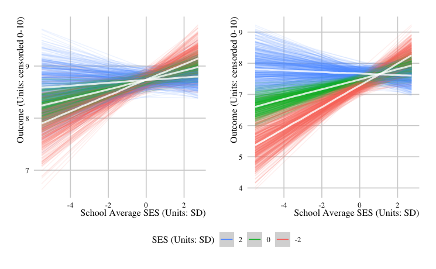

# Discussion

Research on social skills has repeatedly shown that there is a socioeconomic status gradient to social skills (see Datta Gupta and Simonsen 2010; Gutman and Schoon 2013; Jerrim and Sims 2019). Yet little research in this area has considered the potential influence of school context on social skill development (*cf.* Jerrim and Sims 2019). This is a lacuna that our research sought to fill. Our research considered the association of school socioeconomic context with social skills in early elementary school. We used both parent and teacher reported social skills, finding surprisingly consistent effect sizes regardless of reporting source despite their relatively modest agreement. Importantly, our research used a number of critical controls as well as prior social skills that helped us better identify the effect of school average socioeconomic status.

For both teacher and parent reports we found that the association of school context with social skills depended on the individual child’s own socioeconomic background. This was the case for all outcomes except for parent reported prosocial behavior. It is worth emphasizing that the nature of these interactions was consistent for all outcomes. Namely, that middle to high SES children were largely unaffected by school socioeconomic context while the children with the lowest socioeconomic status experienced the largest effect.

## School Context Theory

A greater focus on social skills as explanations for socioeconomic gaps in educational attainment has been an important step forward in inequality research (see Heckman 2006). Now that research and theory has illuminated the importance of such skills, research needs to consider the conditions under which they develop. Previous economic theory has emphasized the role that schools play as a context for the development of non-academic factors like social skills and claimed this as one of the ways in which intergenerational inequality is transmitted (Bowles and Gintis 1976). Such theory has tended to emphasize the role of teachers and systems, relegating students’ fellow classmates to a more secondary role. In contrast, psychology research has tended to emphasize the role of frames-of-reference with particular emphasize given to the role of a child’s peers as providing a standard against which a child might assimilate to or contrast against (Mussweiler, Rüter, and Epstude 2004). It seems likely that both economic and psychology theory is right to some extent but the relative contribution to school context effects of system, teacher, and peers is unclear. Our research shows that school context effects are significant and mainly seem to effect low SES children. Future research is needed to determine what the most important mechanisms are that explain this effect.

## School Context and Assimilation Effects

There are strong arguments and good empirical support on both sides of this debate, suggesting that we are far from a settled position on the matter. At least for the current context in Australia where social stratification is moderately high and where the school system seems to ensure school choice is more clearly an option for the rich than the poor (Parker, Guo, and Sanders 2019), our results are troubling. In particular, they suggest low SES children face a triple bind. First, they enter school with lower social skills. Second, they enter schools where assimilation effects are likely to further dampen social skill development. Third, they appear particularly vulnerable to their school context in this respect.

## Limitations

There are many strengths to this study. Most notably, the use of longitudinal data that allowed for us to control for incoming social skills and government administrative data that provided access to complete and high-quality data for school average socioeconomic status at the school level. Further the use of LSAC data meant that we were able to control for a number of potential confounding variables drawn from a longitudinal representative sample of Australian children. Nevertheless, there are limitations. Our aim was to try to build a model from high-quality data that could assist us in making as close to an *all else being equal* comparisons as possible (Angrist and Pischke 2008). It is for this reason we have cautiously used causal language in relation to our claims. But our claim to causality would have been stronger had they been backed by an experimental design. While the Move to Opportunity program in the US suggest experiments where low SES children are randomly assigned to richer schools (or at least randomly assigned to areas with richer schools) are possible (see de Souza Briggs, Popkin, and Goering 2010), it is hard to imagine a situation in which richer children could be randomly assigned to more disadvantaged schools. Given the non-linearity in effects we observed this would be a serious limitation of an experimental design.

Finally, we were not able to identify and compare the relative impact of different mechanisms that may explain the influence of school average socioeconomic status on social skills. As educational psychologists our study is framed in relation to assimilation effects in response to children’s peer frames-of-reference. Yet, economic theory tends to emphasize the socialization influence of teachers and educational structures (see Bowls & Gintis, 2001). Identifying and comparing these mechanisms is an important future direction for research.

# Conclusion

The influence of school average socioeconomic status on social skills represent the triple disadvantage that low SES children can face in social stratified school systems. First, low SES children are more likely to start school with lower social skills than their high SES peers. Second, because the school system is stratified by socioeconomic status, low SES children are likely to enroll in more disadvantaged schools. Third, assimilative associations suggest low SES children, already disadvantaged by prior social skill gaps, are more affected by their school context than are middle to high SES children. Thus, while low SES children assimilate to lower social skill environments, richer children appear to gain little advantage from their more conducive environments and appear to function equally well in advantaged and disadvantaged schools. Taken together our results support the call for a policy focus that aims to a) decrease country level variance in social stratification, b) decrease between school heterogeneity is social status, and c) in combination with (a), encourage school selection policies that maximize within school heterogeneity in social status.

# References

AIFS, undefined. 2015. “Longitudinal Study of Australian Children Data User Guide.”

Akerlof, George A., and Rachel E. Kranton. 2010. *Identity Economics: How Our Identities Shape Our Work, Wages, and Well-Being*. Princeton: Princeton University Press. https://doi.org/10.1515/9781400834181.

Akerlof, George A, and Rachel E Kranton. 2002. “Identity and Schooling: Some Lessons for the Economics of Education.” *Journal of Economic Literature* 40 (4): 1167–1201. https://doi.org/10.1257/.40.4.1167.

Angrist, Joshua D., and Jörn-Steffen Pischke. 2008. *Mostly Harmless Econometrics: An Empiricist’s Companion*. Princeton university press.

Baker, Kalyca, Mark Sipthorp, and Ben Edwards. 2017. “A Longitudinal Measure of Socioeconomic Position in Lsac.” https://growingupinaustralia.gov.au/sites/default/files/tp18.pdf.

Bowles, Samuel, and Herbert Gintis. 1976. *Schooling in Capitalist America: Educational Reform and the Contradictions of Economic Life*. Routledge & Kegan Paul.

Bürkner, Paul-Christian. 2017. “Brms: An R Package for Bayesian Multilevel Models Using Stan.” *Journal of Statistical Software* 80 (1). https://doi.org/10.18637/jss.v080.i01.

Corcoran, Roisin P., Alan C.K. Cheung, Elizabeth Kim, and Chen Xie. 2018. “Effective Universal School-Based Social and Emotional Learning Programs for Improving Academic Achievement: A Systematic Review and Meta-Analysis of 50 Years of Research.” *Educational Research Review* 25 (November): 56–72. https://doi.org/10.1016/j.edurev.2017.12.001.

Datta Gupta, Nabanita, and Marianne Simonsen. 2010. “Non-Cognitive Child Outcomes and Universal High Quality Child Care.” *Journal of Public Economics* 94 (1-2): 30–43. https://doi.org/10.1016/j.jpubeco.2009.10.001.

de Laat, Sanne A. A., Marie-Louise Essink-Bot, Aleid G. van Wassenaer-Leemhuis, and Tanja G. Vrijkotte. 2016. “Effect of Socioeconomic Status on Psychosocial Problems in 5- to 6-Year-Old Preterm- and Term-Born Children: The Abcd Study.” *European Child & Adolescent Psychiatry* 25 (7): 757–67. https://doi.org/10.1007/s00787-015-0791-4.

de Souza Briggs, Xavier, Susan J. Popkin, and John Goering. 2010. *Moving to Opportunity: The Story of an American Experiment to Fight Ghetto Poverty*. Oxford University Press.

Diamantopoulos, Adamantios, Petra Riefler, and Katharina P. Roth. 2008. “Advancing Formative Measurement Models.” *Journal of Business Research* 61 (12): 1203–18. https://doi.org/10.1016/j.jbusres.2008.01.009.

Durlak, Joseph A., Roger P. Weissberg, Allison B. Dymnicki, Rebecca D. Taylor, and Kriston B. Schellinger. 2011. “The Impact of Enhancing Students’ Social and Emotional Learning: A Meta-Analysis of School-Based Universal Interventions: Social and Emotional Learning.” *Child Development* 82 (1): 405–32. https://doi.org/10.1111/j.1467-8624.2010.01564.x.

Friedman, Milton. 1962. *Capitalism and Freedom*. University of Chicago press.

Garratt, Elisabeth A., Tarani Chandola, Kingsley Purdam, and Alex M. Wood. 2017. “Income and Social Rank Influence Uk Children’s Behavioral Problems: A Longitudinal Analysis.” *Child Development* 88 (4): 1302–20. https://doi.org/10.1111/cdev.12649.

Gradstein, Mark, and Moshe Justman. 2005. “The Melting Pot and School Choice.” *Journal of Public Economics* 89 (5-6): 871–96. https://doi.org/10.1016/j.jpubeco.2004.05.007.

Gutman, Leslie Morrison, and Ingrid Schoon. 2013. “The Impact of Non-Cognitive Skills on Outcomes for Young People.” https://educationendowmentfoundation.org.uk/public/files/Publications/EEF_Lit_Review_Non-CognitiveSkills.pdf.

Heckman, J. J. 2006. “Skill Formation and the Economics of Investing in Disadvantaged Children.” *Science* 312 (5782): 1900–1902. https://doi.org/10.1126/science.1128898.

Honaker, James, Gary King, and Matthew Blackwell. 2011. “Amelia Ii: A Program for Missing Data.” *Journal of Statistical Software* 45 (7): 1–47.

Jerrim, John, and Sam Sims. 2019. “How Do Academically Selective School Systems Affect Pupils’ Social-Emotional Competencies? New Evidence from the Millennium Cohort Study.” *American Educational Research Journal* 56 (5): 1769–99. https://doi.org/10.3102/0002831219830965.

Jones, Damon E., Mark Greenberg, and Max Crowley. 2015. “Early Social-Emotional Functioning and Public Health: The Relationship Between Kindergarten Social Competence and Future Wellness.” *American Journal of Public Health* 105 (11): 2283–90. https://doi.org/10.2105/AJPH.2015.302630.

Kelley, Harold H. 1952. “Two Functions of Reference Groups.” In *Readings in Social Psychology*, edited by Guy E. Swanson, Theodore M. Newcomb, and Eugene L. Hartley, 2:410–14. New York, NY: Henry Holt and Company.

Kleiber, Christian, and Achim Zeileis. 2008. *Applied Econometrics with R*. Springer Science & Business Media.

McMunn, Anne M, James Y Nazroo, Michael G Marmot, Richard Boreham, and Robert Goodman. 2001. “Children’s Emotional and Behavioural Well-Being and the Family Environment: Findings from the Health Survey for England.” *Social Science & Medicine* 53 (4): 423–40. https://doi.org/10.1016/S0277-9536(00)00346-4.

Mussweiler, Thomas, Katja Rüter, and Kai Epstude. 2004. “The Ups and Downs of Social Comparison: Mechanisms of Assimilation and Contrast.” *Journal of Personality and Social Psychology* 87 (6): 832–44. https://doi.org/10.1037/0022-3514.87.6.832.

OECD, undefined. 2015. “How Schools Have Changed over the Past Decade.” http://www.oecd.org/pisa/pisaproducts/pisainfocus/pisa-in-focus-n52-(eng)-final.pdf.

Parker, Philip D., John Jerrim, Ingrid Schoon, and Herbert W. Marsh. 2016. “A Multination Study of Socioeconomic Inequality in Expectations for Progression to Higher Education: The Role of Between-School Tracking and Ability Stratification.” *American Educational Research Journal* 53 (1): 6–32. https://doi.org/10.3102/0002831215621786.

Parker, Philip D., Herbert W. Marsh, Jiesi Guo, Jake Anders, Nikki Shure, and Theresa Dicke. 2018. “An Information Distortion Model of Social Class Differences in Math Self-Concept, Intrinsic Value, and Utility Value.” *Journal of Educational Psychology* 110 (3): 445–63. https://doi.org/10.1037/edu0000215.

Parker, Philip D., Herbert W. Marsh, John P. Jerrim, Jiesi Guo, and Theresa Dicke. 2018. “Inequity and Excellence in Academic Performance: Evidence from 27 Countries.” *American Educational Research Journal* 55 (4): 836–58. https://doi.org/10.3102/0002831218760213.

Parker, Philip, Jiesi Guo, and Taren Sanders. 2019. “Socioeconomic Inequality and Student Outcomes in Australia.” In *Socioeconomic Inequality and Student Outcomes: Cross-National Trends, Policies, and Practices*, edited by Louis Volante, Sylke V. Schnepf, John Jerrim, and Don A. Klinger, 189–204. Singapore: Springer Singapore. https://doi.org/10.1007/978-981-13-9863-6_11.

*Peabody Picture Vocabulary Test–Fourth Edition*. 2007. American Psychological Association. https://doi.org/10.1037/t15144-000.

Rajmil, Luis, Michael Herdman, Ulrike Ravens-Sieberer, Michael Erhart, Jordi Alonso, and undefined The European KIDSCREEN group. 2014. “Socioeconomic Inequalities in Mental Health and Health-Related Quality of Life (Hrqol) in Children and Adolescents from 11 European Countries.” *International Journal of Public Health* 59 (1): 95–105. https://doi.org/10.1007/s00038-013-0479-9.

Reardon, Sean F. 2011. “The Widening Academic Achievement Gap Between the Rich and the Poor: New Evidence and Possible Explanations.” In *Whither Opportunity*, edited by Greg Duncan and Richard Murnane, 91–116. Sage.

Rios, Joseph A., Guangming Ling, Robert Pugh, Dovid Becker, and Adam Bacall. 2020. “Identifying Critical 21st-Century Skills for Workplace Success: A Content Analysis of Job Advertisements.” *Educational Researcher* 49 (2): 80–89. https://doi.org/10.3102/0013189X19890600.

Saporito, Salvatore. 2003. “Private Choices, Public Consequences: Magnet School Choice and Segregation by Race and Poverty.” *Social Problems* 50 (2): 181–203. https://doi.org/10.1525/sp.2003.50.2.181.

*Strengths and Difficulties Questionnaire*. 1997. American Psychological Association. https://doi.org/10.1037/t00540-000.

Thongrattana, Phatcharee Toghaw. 2010. “Assessing Reliability and Validity of a Measurement Instrument for Studying Uncertain Factors in Thai Rice Supply Chain.” In. https://ro.uow.edu.au/sbshdr/2010/papers/4/.

Washbrook, Elizabeth, and Jane Waldfogel. 2011. “On Your Marks: Measuring the School Readiness of Children in Low-to-Middle Income Families.” https://www.resolutionfoundation.org/app/uploads/2014/08/On-your-marks.pdf.

[^1]: We acknowledge that children themselves do not have a socioeconomic status. Rather they are raised in an environment which is shaped by their parents’ socioeconomic status (SES). However, for brevity we refer to children as low SES or high SES hereafter. Likewise, in place of low school average SES and high school average SES we refer to disadvantaged and advantaged schools respectively.
[^2]: This assimilation effect will be indicated by a negative coefficient for peer problems and conduct problems regressed on school average socioeconomic status and a positive coefficient for prosocial behavior regressed on school average socioeconomic status. This is because of the way in which these factors are valanced (high scores indicate high levels of prosocial behavior, but also high levels of peer and conduct problems).
[^3]: Parallel analysis suggested a single principal component was sufficient to account for the variation in the NAPLAN scores.